# Missing data, internal reliability, follow-up

# Note on reverse-coding

When checking internal reliability for the Age Stigma scale, the original coding for individual items in the scale was kept; no items were reverse-coded. After Q4 was dropped, Q5 through Q8 were reverse-coded and the average was calculated to form the “Age Stigma Average” variable.

# Participants excluded due to missing data

back to top

Of 1396 participants with PTA > 25 in their better ear, 643 were excluded due to various amounts of missing data.

## Percentage of missing data per variable

```
## # A tibble: 42 × 3
##    name                  Excluded Included
##    <chr>                    <dbl>    <dbl>
##  1 ID                       0            0
##  2 Age                      0            0
##  3 PTA4_better_ear          0            0
##  4 HHIE_total              11.0          0
##  5 Ability                  8.09         0
##  6 Sex                      0            0
##  7 Edu                      2.33         0
##  8 Married                 28.9          0
##  9 Health                   3.89         0
## 10 QoL                      2.95         0
## 11 Help_neighbours          2.33         0
## 12 Help_problems            2.80         0
```

[output cut: 30 more lines]

## Count of missing data per participant

Note: If Age Stigma item 1 was missing, the whole Age Stigma item was considered missing, even though item 1 was dropped later on.

```
##    Min. 1st Qu.  Median    Mean 3rd Qu.    Max.
##   0.000   1.000   1.000   2.813   3.000  16.000
```

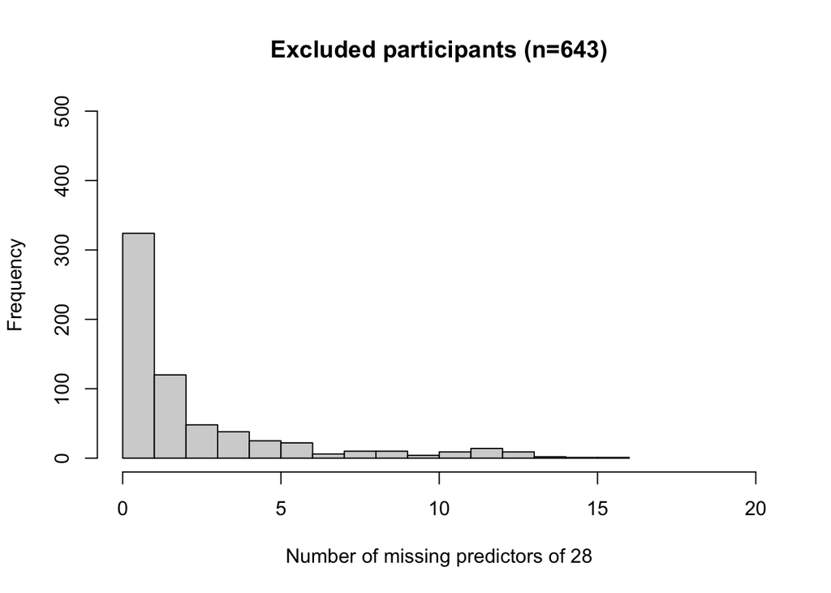

## Descriptives: Excluded vs. Included (No) vs. Included (Yes)

back to top

**Table 1: continuous variables**

```
##           Variable Mean_Ex SD_Ex Mean_InNo SD_InNo Mean_InYes SD_InYes
## 1              Age   71.05  8.75     68.70    8.93      71.42     8.76
## 2  PTA4_better_ear   35.30  8.24     34.81    7.62      36.56     7.46
## 3       HHIE_total   15.81  9.71     15.02    9.36      18.48     9.64
## 4          Ability    6.20  1.75      6.40    1.69       6.08     1.60
## 5              Edu    3.26  1.13      3.35    1.08       3.31     1.19
## 6           Health    3.76  0.90      3.83    0.93       3.86     0.91
## 7              QoL    3.98  0.87      4.09    0.84       4.03     0.88
## 8  Help_neighbours    1.96  0.89      2.00    0.92       1.96     0.87
## 9    Help_problems    2.12  0.79      2.22    0.78       2.17     0.81
## 10         Concern    3.55  1.25      3.67    1.22       3.56     1.29
## 11          Lonely    1.28  0.56      1.22    0.54       1.21     0.56
## 12     Sub_Age_avg    2.90  0.99      2.92    1.00       2.86     0.88
## 13  Age_stigma_avg    2.42  0.94      2.35    0.95       2.46     0.96
## 14   HA_stigma_avg    2.78  1.07      2.91    1.05       2.71     1.06
```

**Table 1: binary variables**

```
##                 Variable Excl InclNoHA InclYesHA
## 1                    Sex 0.51     0.58      0.54
## 2                Married 0.74     0.77      0.77
## 3                 Accomp 0.14     0.15      0.19
## 4         Soc_Suspect_HL 0.88     0.84      0.93
## 5            Soc_Know_HL 0.87     0.85      0.85
## 6         Soc_Discuss_HL 0.52     0.49      0.46
## 7       Soc_Hearing_test 0.64     0.65      0.65
## 8          Soc_Obtain_HA 0.71     0.71      0.72
## 9      Soc_Sometimes_use 0.56     0.53      0.54
## 10       Soc_Regular_use 0.71     0.66      0.68
## 11     Soc_Very_positive 0.64     0.58      0.64
## 12 Soc_Somewhat_positive 0.57     0.53      0.52
## 13 Soc_Somewhat_negative 0.41     0.35      0.36
## 14     Soc_Very_negative 0.24     0.17      0.19
```

## Comparing excluded and included participants

back to top

Continuous variables

```
##           Variable Mean_Excl SD_Excl Mean_Incl SD_Incl     t      p cohens_d
## 1              Age     71.05    8.75     69.24    8.96  3.80 0.0001    0.204
## 2  PTA4_better_ear     35.30    8.24     35.15    7.61  0.35 0.7268    0.019
## 3       HHIE_total     15.81    9.71     15.70    9.51  0.20 0.8388    0.011
## 4          Ability      6.20    1.75      6.33    1.68 -1.40 0.1633   -0.077
## 5              Edu      3.26    1.13      3.34    1.10 -1.28 0.2018   -0.069
## 6           Health      3.76    0.90      3.84    0.92 -1.51 0.1319   -0.082
## 7              QoL      3.98    0.87      4.08    0.85 -2.05 0.0402   -0.112
## 8  Help_neighbours      1.96    0.89      1.99    0.91 -0.68 0.4973   -0.037
## 9    Help_problems      2.12    0.79      2.21    0.79 -2.13 0.0336   -0.115
## 10         Concern      3.55    1.25      3.65    1.24 -1.43 0.1533   -0.078
## 11          Lonely      1.28    0.56      1.21    0.54  2.22 0.0263    0.121
## 12        SubAge_1      2.89    1.19      2.89    1.12 -0.04 0.9663   -0.002
## 13        SubAge_2      2.85    1.09      2.85    1.09  0.02 0.9861    0.001
## 14        SubAge_3      2.97    1.10      2.98    1.10 -0.20 0.8431   -0.011
## 15     AgeStigma_1      2.62    1.03      2.59    1.01  0.60 0.5466    0.033
## 16     AgeStigma_2      3.30    1.13      3.33    1.14 -0.59 0.5520   -0.032
## 17     AgeStigma_3      3.67    1.18      3.68    1.18 -0.15 0.8839   -0.008
## 18     AgeStigma_4      3.64    1.18      3.70    1.16 -0.96 0.3383   -0.052
## 19     AgeStigma_5      3.71    1.18      3.80    1.13 -1.44 0.1507   -0.078
## 20      HaStigma_1      3.11    1.18      3.20    1.16 -1.36 0.1725   -0.074
## 21      HaStigma_2      2.70    1.21      2.78    1.23 -1.32 0.1854   -0.071
## 22      HaStigma_3      2.83    1.23      2.96    1.26 -1.95 0.0515   -0.105
## 23      HaStigma_4      2.47    1.21      2.54    1.21 -1.10 0.2709   -0.059
```

Binary variables  
(Note: Proportions refer to Sex=Male, Married=Yes, Accompanied=Yes, Soc…=Yes)

```
##                 Variable Proportion_Excl Proportion_Incl chisq p_value cohens_h
## 1                    Sex           0.509           0.574 5.674  0.0172   -0.131
## 2                Married           0.744           0.772 1.045  0.3068   -0.064
## 3                 Accomp           0.143           0.157 0.381  0.5370   -0.038
## 4         Soc_Suspect_HL           0.876           0.859 0.686  0.4076    0.050
## 5            Soc_Know_HL           0.866           0.847 0.829  0.3627    0.055
## 6         Soc_Discuss_HL           0.520           0.485 1.430  0.2318    0.070
## 7       Soc_Hearing_test           0.644           0.648 0.008  0.9281   -0.009
## 8          Soc_Obtain_HA           0.711           0.714 0.009  0.9236   -0.009
## 9      Soc_Sometimes_use           0.559           0.530 0.900  0.3429    0.058
## 10       Soc_Regular_use           0.710           0.661 3.163  0.0753    0.104
## 11     Soc_Very_positive           0.643           0.594 2.910  0.0880    0.102
## 12 Soc_Somewhat_positive           0.568           0.527 1.788  0.1812    0.081
## 13 Soc_Somewhat_negative           0.411           0.353 3.926  0.0475    0.118
## 14     Soc_Very_negative           0.241           0.171 8.398  0.0038    0.172
```

## Takeaway re: Included vs Excluded

Excluded and included participants were generally similar. For statistically significant differences, the effect size never exceeded *d*=0.2 (small).

## Comparing ‘Yes’ and ‘No’ purchase, within included participants

back to top

Continuous variables

```
##           Variable Mean_No SD_No Mean_Yes SD_Yes     t      p
## 1              Age   68.70  8.93    71.42   8.76 -3.38 0.0009
## 2  PTA4_better_ear   34.81  7.62    36.56   7.46 -2.56 0.0112
## 3       HHIE_total   15.02  9.36    18.48   9.64 -3.95 0.0001
## 4          Ability    6.40  1.69     6.08   1.60  2.12 0.0347
## 5              Edu    3.35  1.08     3.31   1.19  0.38 0.7047
## 6           Health    3.83  0.93     3.86   0.91 -0.33 0.7380
## 7              QoL    4.09  0.84     4.03   0.88  0.82 0.4118
## 8  Help_neighbours    2.00  0.92     1.96   0.87  0.54 0.5881
## 9    Help_problems    2.22  0.78     2.17   0.81  0.64 0.5211
## 10         Concern    3.67  1.22     3.56   1.29  1.00 0.3187
## 11          Lonely    1.22  0.54     1.21   0.56  0.14 0.8881
## 12        SubAge_1    2.90  1.13     2.87   1.05  0.31 0.7596
## 13        SubAge_2    2.85  1.11     2.85   1.02 -0.03 0.9748
## 14        SubAge_3    3.01  1.10     2.87   1.12  1.34 0.1803
## 15     Sub_Age_avg    2.92  1.00     2.86   0.88  0.66 0.5068
## 16     AgeStigma_1    2.60  1.02     2.57   0.99  0.28 0.7790
## 17     AgeStigma_2    3.35  1.13     3.26   1.18  0.85 0.3956
## 18     AgeStigma_3    3.69  1.18     3.63   1.16  0.53 0.5993
## 19     AgeStigma_4    3.72  1.16     3.64   1.17  0.73 0.4683
## 20     AgeStigma_5    3.83  1.12     3.64   1.17  1.78 0.0771
## 21  Age_stigma_avg    2.35  0.95     2.46   0.96 -1.18 0.2382
## 22      HaStigma_1    3.22  1.15     3.11   1.24  1.00 0.3199
## 23      HaStigma_2    2.83  1.23     2.58   1.22  2.21 0.0279
## 24      HaStigma_3    3.01  1.25     2.78   1.27  2.00 0.0465
## 25      HaStigma_4    2.58  1.22     2.38   1.19  1.88 0.0614
## 26   HA_stigma_avg    2.91  1.05     2.71   1.06  2.05 0.0416
```

Binary variables  
(Note: Proportions refer to Sex=Male, Married=Yes, Accompanied=Yes, Soc…=Yes)

```
##                 Variable Proportion_No Proportion_Yes chisq p_value
## 1                    Sex         0.583          0.537 0.849  0.3568
## 2                Married         0.773          0.765 0.010  0.9192
## 3                 Accomp         0.147          0.195 1.680  0.1950
## 4         Soc_Suspect_HL         0.843          0.926 6.210  0.0127
## 5            Soc_Know_HL         0.848          0.846 0.000  1.0000
## 6         Soc_Discuss_HL         0.492          0.456 0.465  0.4954
## 7       Soc_Hearing_test         0.647          0.651 0.000  1.0000
## 8          Soc_Obtain_HA         0.712          0.725 0.045  0.8327
## 9      Soc_Sometimes_use         0.528          0.537 0.010  0.9200
## 10       Soc_Regular_use         0.657          0.678 0.143  0.7051
## 11     Soc_Very_positive         0.581          0.644 1.724  0.1892
## 12 Soc_Somewhat_positive         0.528          0.523 0.000  0.9917
## 13 Soc_Somewhat_negative         0.353          0.356 0.000  1.0000
## 14     Soc_Very_negative         0.166          0.195 0.521  0.4703
```

# Internal reliability of scales

back to top

**Cronbach’s alpha**  
A measure of internal reliability of items in a questionnaire, ranging from 0 (items are entirely independent) to 1 (items are highly correlated). Standards are arbitrary and depend on the field, but ≤ 0.5 is generally not good if all items are supposed to measure the same concept.

## Subjective age

For Subjective Age items in n=753, Cronbach’s alpha = 0.86, showing good internal reliability of items. Dropping each item in turn does not have a big impact (alpha = 0.78 to 0.82), and individual items are well-correlated with the total score (r = 0.87 to 0.89).

```
##          SbA_1 SbA_2 SbA_3
## SubAge_1 1.00
## SubAge_2 0.67  1.00
## SubAge_3 0.64  0.69  1.00
```

```
##
## Reliability analysis
## Call: alpha(x = sub_age, check.keys = FALSE, n.iter = 500)
##
##   raw_alpha std.alpha G6(smc) average_r S/N   ase mean   sd median_r
##       0.86      0.86     0.8      0.67   6 0.009  2.9 0.97     0.67
##
##     95% confidence boundaries
##              lower alpha upper
## Feldt         0.84  0.86  0.87
## Duhachek      0.84  0.86  0.87
## bootstrapped  0.83  0.86  0.88
##
##  Reliability if an item is dropped:
##          raw_alpha std.alpha G6(smc) average_r S/N alpha se var.r med.r
## SubAge_1      0.82      0.82    0.69      0.69 4.5    0.013    NA  0.69
## SubAge_2      0.78      0.78    0.64      0.64 3.6    0.016    NA  0.64
## SubAge_3      0.80      0.80    0.67      0.67 4.0    0.015    NA  0.67
##
##  Item statistics
##            n raw.r std.r r.cor r.drop mean  sd
## SubAge_1 753  0.87  0.87  0.77   0.71  2.9 1.1
## SubAge_2 753  0.89  0.89  0.81   0.75  2.8 1.1
## SubAge_3 753  0.88  0.88  0.79   0.73  3.0 1.1
##
## Non missing response frequency for each item
##             1    2    3    4    5    6 7 miss
## SubAge_1 0.08 0.34 0.29 0.21 0.06 0.01 0    0
## SubAge_2 0.09 0.33 0.28 0.25 0.04 0.01 0    0
## SubAge_3 0.08 0.29 0.28 0.29 0.05 0.01 0    0
```

## Age stigma

For Age Stigma items in n=753, dropping item 1 would improve Cronbach’s alpha from 0.73 to 0.85, while dropping any other item would lower it from 0.73 to 0.60-0.65. Item 1 is poorly correlated with the total Age Stigma score (r = 0.22) while other items are well-correlated with the total score (r = 0.75 to 0.82).

```
##             AgS_1 AgS_2 AgS_3 AgS_4 AgS_5
## AgeStigma_1  1.00
## AgeStigma_2 -0.07  1.00
## AgeStigma_3 -0.07  0.59  1.00
## AgeStigma_4  0.03  0.48  0.58  1.00
## AgeStigma_5 -0.02  0.51  0.60  0.70  1.00
```

```
##
## Reliability analysis
## Call: alpha(x = age_stigma, check.keys = FALSE, n.iter = 500)
##
##   raw_alpha std.alpha G6(smc) average_r S/N   ase mean   sd median_r
##       0.73      0.71    0.74      0.33 2.5 0.015  3.4 0.78      0.5
##
##     95% confidence boundaries
##              lower alpha upper
## Feldt         0.70  0.73  0.76
## Duhachek      0.70  0.73  0.76
## bootstrapped  0.69  0.73  0.77
##
##  Reliability if an item is dropped:
##             raw_alpha std.alpha G6(smc) average_r S/N alpha se  var.r med.r
## AgeStigma_1      0.85      0.85    0.81      0.58 5.5   0.0093 0.0055  0.59
## AgeStigma_2      0.65      0.63    0.67      0.30 1.7   0.0195 0.1267  0.30
## AgeStigma_3      0.62      0.60    0.63      0.27 1.5   0.0215 0.1078  0.26
## AgeStigma_4      0.60      0.58    0.61      0.26 1.4   0.0223 0.1161  0.25
## AgeStigma_5      0.61      0.58    0.61      0.26 1.4   0.0223 0.1063  0.26
##
##  Item statistics
##               n raw.r std.r  r.cor r.drop mean  sd
## AgeStigma_1 753  0.22  0.26 -0.037 -0.038  2.6 1.0
## AgeStigma_2 753  0.75  0.74  0.653  0.564  3.3 1.1
## AgeStigma_3 753  0.80  0.79  0.745  0.641  3.7 1.2
## AgeStigma_4 753  0.82  0.82  0.789  0.679  3.7 1.2
## AgeStigma_5 753  0.82  0.82  0.794  0.682  3.8 1.1
##
## Non missing response frequency for each item
##                1    2    3    4    5 miss
## AgeStigma_1 0.20 0.19 0.48 0.11 0.03    0
## AgeStigma_2 0.06 0.16 0.34 0.24 0.19    0
## AgeStigma_3 0.06 0.12 0.23 0.30 0.30    0
## AgeStigma_4 0.06 0.09 0.26 0.29 0.31    0
## AgeStigma_5 0.05 0.08 0.25 0.29 0.34    0
```

Age Stigma items 4 and 5 are the most highly correlated items with the overall scale, so they’re a good exemplar of what the scatterplot should look like, with a strong diagonal. Item 1 (the odd one out) doesn’t look like it’s a simple reversal issue. More people chose “3” (neither agree nor disagree) compared to the other scales, which suggests they didn’t know what to make of this question.

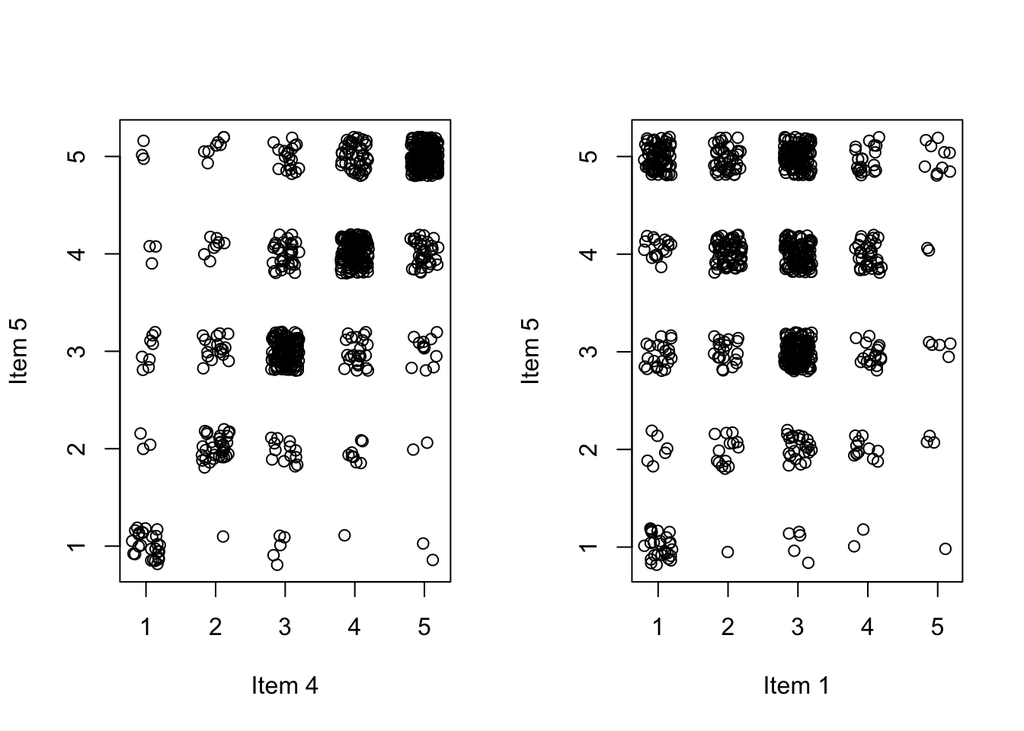

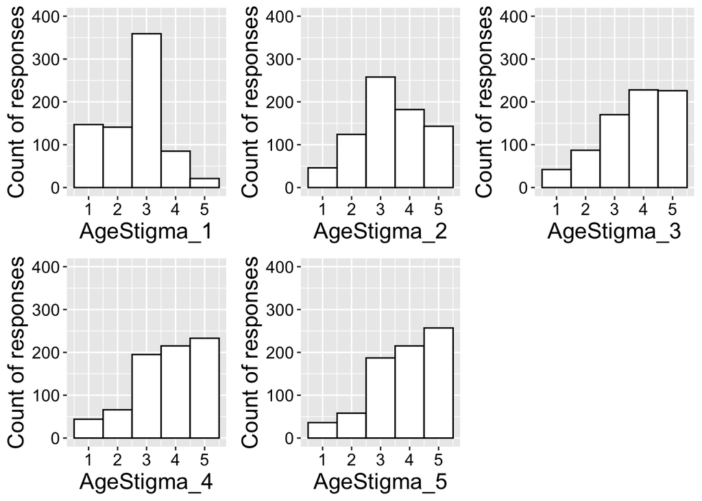

## Hearing aid stigma

For Hearing Aid Stigma items in n=753, Cronbach’s alpha = 0.89, showing good internal reliability of items. Dropping each item in turn does not have a big impact (alpha = 0.83 to 0.90), and individual items are well-correlated with the total score (r = 0.80 to 0.91).

```
##            HSt_1 HSt_2 HSt_3 HSt_4
## HaStigma_1 1.00
## HaStigma_2 0.63  1.00
## HaStigma_3 0.63  0.72  1.00
## HaStigma_4 0.54  0.80  0.70  1.00
```

```
##
## Reliability analysis
## Call: alpha(x = ha_stigma, check.keys = FALSE, n.iter = 500)
##
##   raw_alpha std.alpha G6(smc) average_r S/N    ase mean  sd median_r
##       0.89      0.89    0.87      0.67 8.2 0.0065  2.9 1.1     0.67
##
##     95% confidence boundaries
##              lower alpha upper
## Feldt         0.88  0.89  0.90
## Duhachek      0.88  0.89  0.90
## bootstrapped  0.87  0.89  0.91
##
##  Reliability if an item is dropped:
##            raw_alpha std.alpha G6(smc) average_r S/N alpha se  var.r med.r
## HaStigma_1      0.90      0.90    0.86      0.74 8.6   0.0067 0.0029  0.72
## HaStigma_2      0.83      0.83    0.78      0.62 5.0   0.0105 0.0062  0.63
## HaStigma_3      0.85      0.85    0.82      0.66 5.8   0.0093 0.0172  0.63
## HaStigma_4      0.85      0.85    0.80      0.66 5.8   0.0092 0.0026  0.63
##
##  Item statistics
##              n raw.r std.r r.cor r.drop mean  sd
## HaStigma_1 753  0.80  0.81  0.70   0.66  3.2 1.2
## HaStigma_2 753  0.91  0.91  0.89   0.83  2.8 1.2
## HaStigma_3 753  0.88  0.88  0.82   0.78  3.0 1.3
## HaStigma_4 753  0.88  0.88  0.84   0.78  2.5 1.2
##
## Non missing response frequency for each item
##               1    2    3    4    5 miss
## HaStigma_1 0.12 0.10 0.37 0.27 0.14    0
## HaStigma_2 0.21 0.17 0.35 0.18 0.09    0
## HaStigma_3 0.18 0.14 0.31 0.25 0.11    0
## HaStigma_4 0.27 0.19 0.35 0.13 0.07    0
```

# Comparing correlations within larger sample to n=753 sample

back to top

There were 1309 participants who were aged 50+, had never used a hearing aid, had PTA (better ear) > 25, and had complete data for all items in Subjective Age, Age Stigma, and Hearing Aid Stigma.

Correlation matrices look similar between the broader sample of n=1309 and the smaller sample of n=753 who had complete data in other variables of interest.

**Subjective Age (n=1309)**

```
##          SbA_1 SbA_2 SbA_3
## SubAge_1 1.00
## SubAge_2 0.65  1.00
## SubAge_3 0.65  0.69  1.00
```

**Subjective Age (n=753)**

```
##          SbA_1 SbA_2 SbA_3
## SubAge_1 1.00
## SubAge_2 0.67  1.00
## SubAge_3 0.64  0.69  1.00
```

**Age Stigma (n=1309)**

```
##             AgS_1 AgS_2 AgS_3 AgS_4 AgS_5
## AgeStigma_1  1.00
## AgeStigma_2 -0.06  1.00
## AgeStigma_3 -0.05  0.56  1.00
## AgeStigma_4 -0.01  0.47  0.56  1.00
## AgeStigma_5 -0.04  0.47  0.57  0.66  1.00
```

**Age Stigma (n=753)**

```
##             AgS_1 AgS_2 AgS_3 AgS_4 AgS_5
## AgeStigma_1  1.00
## AgeStigma_2 -0.07  1.00
## AgeStigma_3 -0.07  0.59  1.00
## AgeStigma_4  0.03  0.48  0.58  1.00
## AgeStigma_5 -0.02  0.51  0.60  0.70  1.00
```

**Hearing Aid Stigma (n=1309)**

```
##            HSt_1 HSt_2 HSt_3 HSt_4
## HaStigma_1 1.00
## HaStigma_2 0.67  1.00
## HaStigma_3 0.66  0.71  1.00
## HaStigma_4 0.58  0.79  0.71  1.00
```

**Hearing Aid Stigma (n=753)**

```
##            HSt_1 HSt_2 HSt_3 HSt_4
## HaStigma_1 1.00
## HaStigma_2 0.63  1.00
## HaStigma_3 0.63  0.72  1.00
## HaStigma_4 0.54  0.80  0.70  1.00
```

## Takeaways

1. We are justified in dropping the first Age Stigma item (Q4 in the original survey), and averaging items within each scale for Subjective Age, Age Stigma and HA Stigma.
2. Correlation matrices are similar when looking at a larger sample of n=1309 and the current sample of n=753.

# Duration of follow-up

back to top

## Date information

The date information is somewhat messy. 32% of 753 participants are missing a “date of first visit”, and 2 people had their “most recent visit” a year *before* their “first visit”, which is likely an error. It’s also not clear when a participant first had their hearing tested, as the date of the “most recent hearing eval” doesn’t always coincide with the “date of first visit”.

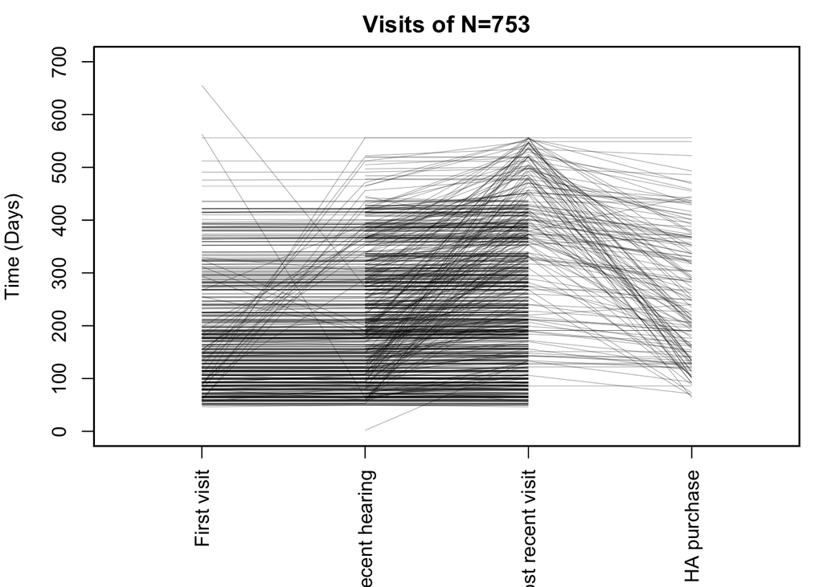

To get around missing data and inconsistent dates, I set the participant’s “first visit” as the earliest of the three dates “first visit”, “most recent hearing eval” and “most recent visit”. The final spreadsheet from the study coordinator was dated July 30, 2019, so I set Jul-30-2019 as the study end date.

Number of days each person was in the study = end date - first visit date.

## Tracking HA purchase over time

Most participants were in the study between 3 and 16 months (below).

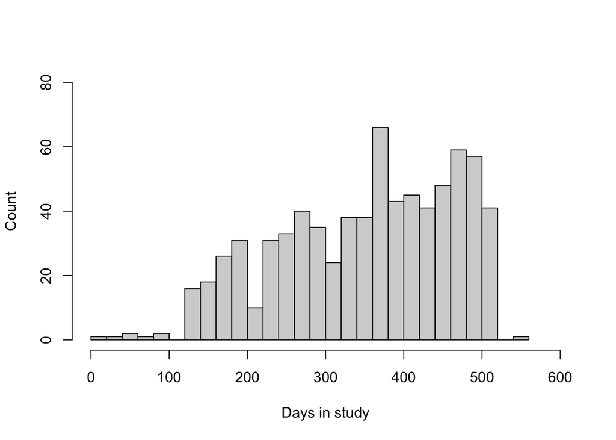

By Day 90 in the study, 81.595% of participants who were going to buy hearing aids by the end of the study had already done so (below). (Note: 5 participants who purchased HA were excluded from these analyses because they had no “study duration” info; they were were missing “first visit” dates and their remaining dates were after their purchase date.)

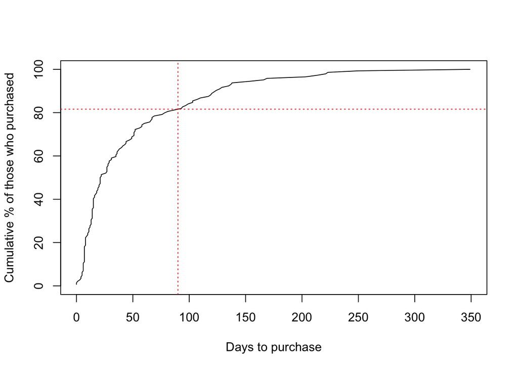

I sorted participants into 90-day bins depending on how long they were each in the study (0-90 days, 91-180 days, until 540+ days; every participant is only in one bin). The proportion of participants who purchased hearing aids was fairly steady regardless of how long they were followed; a Pearson’s chi-squared test of independence showed no difference in proportions across bins (excluding bin 1 and 7 because there were too few observations in each cell).

```
##          90-day bins
## Purchased   1   2   3   4   5   6   7
##       No    3  52  97 133 170 149   0
##       Yes   3   9  24  26  53  28   1
```

```
##          90-day bins
## Purchased         1         2         3         4         5         6         7
##       No  0.5000000 0.8524590 0.8016529 0.8364780 0.7623318 0.8418079 0.0000000
##       Yes 0.5000000 0.1475410 0.1983471 0.1635220 0.2376682 0.1581921 1.0000000
```

```
##
##  Pearson's Chi-squared test
##
## data:  t
## X-squared = 5.9699, df = 4, p-value = 0.2014
```

## Takeaway

If people are going to purchase hearing aids, >80% do so in the first three months. Following people for longer doesn’t change the rate of hearing aid uptake.